# part2_sequence_diversity

mcgrathjes

2025-10-06

## Part 2 - Examining biological sequence diversity

This report will analyse the biological sequence features of *Salmonella enterica subsp. enterica serovar Weltevreden (GCA_005518735)* and compare it against *Escherichia coli str. K-12 substr. MG1655 str. K12 (GCA_000005845)* in order to examine the biological sequence diversity of the two organisms.

#### 1. Download the whole set of coding DNA sequences for E. coli and your organism of interest. How many coding sequences are present in these organisms? Present this in the form of a table. Describe any differences between the two organisms.

We will be downloading *S. Weltevreden* and *E. coli* genomic sequence data from one of the biggest databases of genomic data - Ensembl https://bacteria.ensembl.org/index.html. There are many E. coli strains available in Ensembl, but as previously described, we will focus today on “Escherichia coli str. K-12 substr. MG1655 str. K12 (GCA_000005845)”.

We will download the sequences into R with the **seqinr** package and decompress them with the **R.utils** package.

Load *E. coli* and *S. Weltevreden* genomes, unzip and list the files to confirm successful:

```
## [1] "ecoli_cds.fa"                  "ecoli_cds.fa.gz"
## [3] "part2_sequence_diversity.html" "part2_sequence_diversity.Rmd"
## [5] "sweltevreden_cds.fa"           "sweltevreden_cds.fa.gz"
```

We will now read in the fasta files using **seqinr::read.fast()** to create a “cds” list, assess how many coding sequences are present using **length()** for each organism, and finally create a table using the **knitr::kable** function of R to compare the two files.

Number of coding sequences in each organism

| File | Num_CDS |
| --- | --- |
| ecoli_cds.fa | 4239 |
| sweltevreden_cds.fa | 4585 |

We can see that there are **4239** coding sequences in *E. coli* and **4585** coding sequences in *S. weltevreden* demonstrating that S. weltevreden has more coding sequences than E. coli.

This difference may be indicative of genome size variation, strain-specific genes, differing regulatory systems or mutations (insertions, deletions, or substitutions of nucleotides), which lead to genetic variation over evolutionary time (Winfield and Groisman, 2004).

#### 2. How much coding DNA is there in total for these two organisms? Present this in the form of a table. Describe any differences between the two organisms.

By extracting the gene lengths for each organism using the **summary()** function, we can convert the first column of the output into a numeric vector (e.g., `ecoli_len <- as.numeric(summary(ecoli_cds)[,1])`), before calculating the total length of all genes by summing them.

Total coding DNA in sample organism genomes

| Organism | Total_Coding_DNA_bp |
| --- | --- |
| E. coli | 3978528 |
| S. weltevreden | 4294851 |

We can see that E. coli has **3.98Mbp** of coding DNA and S. weltevreden has **4.29Mbp**.

Whilst both organisms have similar total coding DNA lengths, there are more bp’s present in the S. weltevreden genome by approximately 0.316Mbp which may reflect additional genes or a slightly larger genome.

#### 3. Calculate the length of all coding sequences in these two organisms. Make a boxplot of coding sequence length in these organisms. What is the mean and median coding sequence length of these two organisms? Describe any differences between the two organisms.

By using the total length object of each respective organism calculated in the previous section, we can add these totals together to produce a new `combined_total` object.

```r
combined_total <- ecoli_total + sweltevreden_total
combined_total
```

```
## [1] 8273379
```

This calculation demonstrates a combined total length of all coding sequences in our two organism genomes of **8.27Mbp**.

[figure not shown]

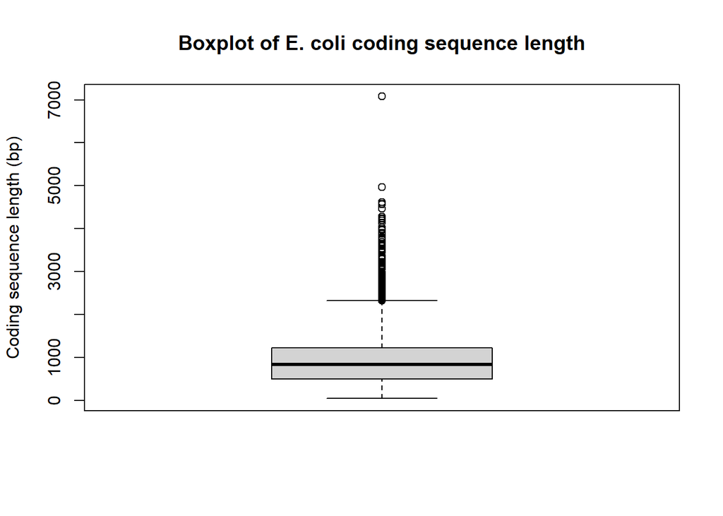

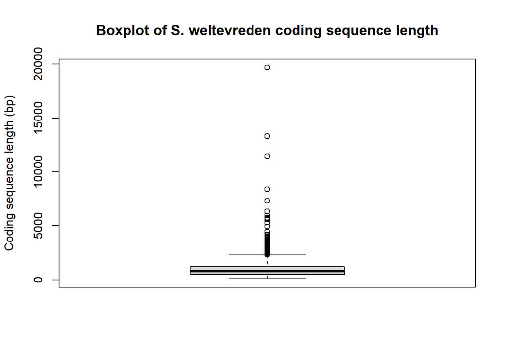

The distribution of these boxplots show a right skew with several outliers that lengthen the whiskers towards the upper maximum limits.

These observations are supported by calculating the mean and median values of individual organisms, and a new combined vector which is created by:

```r
# Combine the lengths into a single vector
combined_len <- c(ecoli_len, sweltevreden_len)
```

```r
# Calculate mean combined
mean_len <- mean(combined_len)
mean_len
```

```
## [1] 937.5996
```

```r
# Calculate median combined
median_len <- median(combined_len)
median_len
```

```
## [1] 816
```

The mean coding sequence length of these two organisms combined is **937.6bp** and the median coding sequence length is **816bp**.

```r
# E. coli
ecoli_len <- as.numeric(summary(ecoli_cds)[,1])
mean(ecoli_len)
```

```
## [1] 938.5534
```

```r
median(ecoli_len)
```

```
## [1] 831
```

```r
# S. weltevreden
sweltevreden_len <- as.numeric(summary(sweltevreden_cds)[,1])
mean(sweltevreden_len)
```

```
## [1] 936.7178
```

```r
median(sweltevreden_len)
```

```
## [1] 804
```

Individually, E.coli has a mean sequence length of **938.6bp** and median of **831bp**, whilst S. weltevreden mean is slightly lower at **936.7bp** and lower median of **804bp**.

This indicates that although both organisms have similar average gene sizes, S. weltevreden may possess a greater number of shorter coding sequences. Such variation could reflect differences in genome organisation, gene density, or the presence of smaller accessory genes that contribute to environmental adaptation or virulence (McClelland et al., 2001).

#### 4. Calculate the frequency of DNA bases in the total coding sequences for both organisms. Perform the same calculation for the total protein sequence. Create bar plots for nucleotide and amino acid frequency. Describe any differences between the two organisms.

In order to compute the frequency of DNA bases in the organism coding sequence data sets, we first need to unlist both cds objects, and store the sequences in a “_dna” variable.

We then calculate the frequency of each nucleotide using `<organism>_composition <- count(<organism>_dna, 1)`, which stores these total counts in _composition. We can further examine these counts as relative frequency _proportion using `<organism>_proportion <- <organism>_composition/sum(<organism>_composition)`.

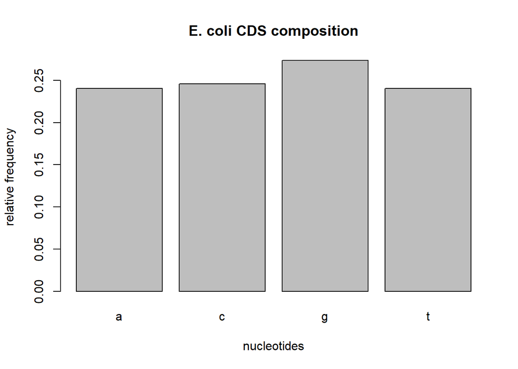

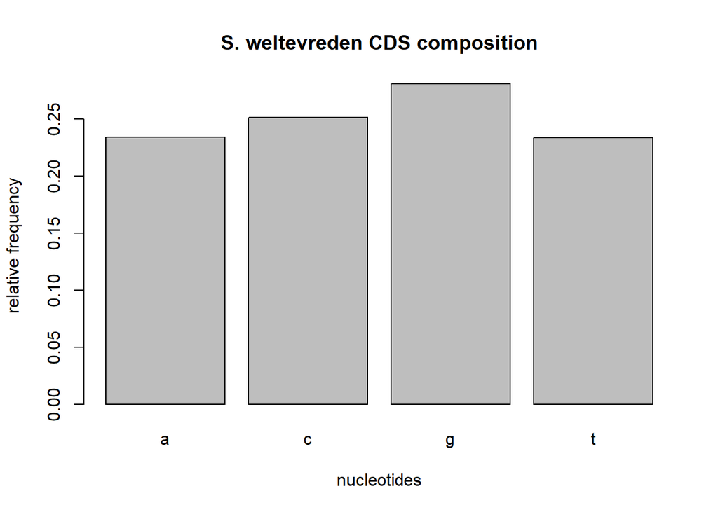

We can see that both organisms have a very similar composition with the highest proportion of nucleotides being **Guanine (G)** of greater than 25%.

**Dear markers:** I have made an error somewhere so my objects are not containing the correct information from this point on. I have tried and tried to troubleshoot and have left off below trying to read the cds back in, translate and then unlist it again. I have included the commands to be used for the next sections but note there is incorrect output.

Thank you for your consideration in part marks.

Below we have read in the cds files for each organism and used **lapply**’s **translate** function to create a list of protein sequences. We attempt to unlist again to replicate the previous successful calculation step to count and quantify the frequency of amino acids.

```r
ecoli_cds <- seqinr::read.fasta("ecoli_cds.fa")
ecoli_prot <- lapply(ecoli_cds, translate)
ecoli_prot_seq <- unlist(ecoli_prot)
ecoli_aa <- count(ecoli_prot,1)
ecoli_aa_prop <- ecoli_aa/sum(ecoli_aa)
ecoli_aa_prop
```

```
##
## a c g t
##
```

```r
#barplot(ecoli_aa_prop,
        #xlab="amino acids",
        #ylab="relative frequency",
        #main="E. coli amino acid composition")


sweltevreden_cds <- seqinr::read.fasta("sweltevreden_cds.fa")
sweltevreden_prot <- lapply(sweltevreden_cds, translate)
sweltevreden_prot_seq <- unlist(sweltevreden_prot)
sweltevreden_aa <- count(sweltevreden_prot_seq,1)
sweltevreden_aa_prop <- sweltevreden_aa / sum(sweltevreden_aa)
sweltevreden_aa_prop
```

```
##
## a c g t
##
```

```r
#barplot(sweltevreden_aa_prop,
        #xlab="amino acids",
        #ylab="relative frequency",
        #main="S. weltevreden amino acid composition")
```

#### 5. Create a codon usage table and quantify the codon usage bias among all coding sequences. Describe any differences between the two organisms with respect to their codon usage bias. Provide charts to support your observations.

Using the **Seqinr** packages command **uco**, we can create a codon usage table for our organisms.

We can then quantify the codon usage bias by using `index="rscu"` which computes the Relative Synonymous Codon Usage (RSCU) values and expresses how preferred a codon of a particular amino acid is compared to the other codons which also encode it.

E. coli

```r
uco(ecoli_cds)
```

```
##
## aaa aac aag aat aca acc acg act aga agc agg agt ata atc atg att caa cac cag cat
##   0   0   0   0   0   0   0   0   0   0   0   0   0   0   0   0   0   0   0   0
## cca ccc ccg cct cga cgc cgg cgt cta ctc ctg ctt gaa gac gag gat gca gcc gcg gct
##   0   0   0   0   0   0   0   0   0   0   0   0   0   0   0   0   0   0   0   0
## gga ggc ggg ggt gta gtc gtg gtt taa tac tag tat tca tcc tcg tct tga tgc tgg tgt
##   0   0   0   0   0   0   0   0   0   0   0   0   0   0   0   0   0   0   0   0
## tta ttc ttg ttt
##   0   0   0   0
```

```r
uco(ecoli_cds,index="rscu")
```

```
## aaa aac aag aat aca acc acg act aga agc agg agt ata atc atg att caa cac cag cat
##  NA  NA  NA  NA  NA  NA  NA  NA  NA  NA  NA  NA  NA  NA  NA  NA  NA  NA  NA  NA
## cca ccc ccg cct cga cgc cgg cgt cta ctc ctg ctt gaa gac gag gat gca gcc gcg gct
##  NA  NA  NA  NA  NA  NA  NA  NA  NA  NA  NA  NA  NA  NA  NA  NA  NA  NA  NA  NA
## gga ggc ggg ggt gta gtc gtg gtt taa tac tag tat tca tcc tcg tct tga tgc tgg tgt
##  NA  NA  NA  NA  NA  NA  NA  NA  NA  NA  NA  NA  NA  NA  NA  NA  NA  NA  NA  NA
## tta ttc ttg ttt
##  NA  NA  NA  NA
```

S. weltevreden

```r
uco(sweltevreden_cds)
```

```
##
## aaa aac aag aat aca acc acg act aga agc agg agt ata atc atg att caa cac cag cat
##   0   0   0   0   0   0   0   0   0   0   0   0   0   0   0   0   0   0   0   0
## cca ccc ccg cct cga cgc cgg cgt cta ctc ctg ctt gaa gac gag gat gca gcc gcg gct
##   0   0   0   0   0   0   0   0   0   0   0   0   0   0   0   0   0   0   0   0
## gga ggc ggg ggt gta gtc gtg gtt taa tac tag tat tca tcc tcg tct tga tgc tgg tgt
##   0   0   0   0   0   0   0   0   0   0   0   0   0   0   0   0   0   0   0   0
## tta ttc ttg ttt
##   0   0   0   0
```

```r
uco(sweltevreden_cds,index="rscu")
```

```
## aaa aac aag aat aca acc acg act aga agc agg agt ata atc atg att caa cac cag cat
##  NA  NA  NA  NA  NA  NA  NA  NA  NA  NA  NA  NA  NA  NA  NA  NA  NA  NA  NA  NA
## cca ccc ccg cct cga cgc cgg cgt cta ctc ctg ctt gaa gac gag gat gca gcc gcg gct
##  NA  NA  NA  NA  NA  NA  NA  NA  NA  NA  NA  NA  NA  NA  NA  NA  NA  NA  NA  NA
## gga ggc ggg ggt gta gtc gtg gtt taa tac tag tat tca tcc tcg tct tga tgc tgg tgt
##  NA  NA  NA  NA  NA  NA  NA  NA  NA  NA  NA  NA  NA  NA  NA  NA  NA  NA  NA  NA
## tta ttc ttg ttt
##  NA  NA  NA  NA
```

#### 6. In the organism of interest, identify 10 protein sequence k-mers of length 3-5 which are the most over- and under-represented k-mers in your organism of interest. Are these k-mers also over- and under-represented in E. coli to a similar extent? Provide plots to support your observations. Why do you think these sequences are present at different levels in the genomes of these organisms?